# Illinois 2017 Exploratory Data Analysis

2/17/2020

## Setup Directory and Import Libraries.

Here we import important libraries and set the file path.

```r
#Change file path here. Data can be downloaded from HMDA website.
file_path <- "/Users/omkarpawar/Desktop/Data/IL/hmda_2017_il_all-records_labels.csv"

library(corrplot)
library(ggplot2)
library(tidyr)
library(stringr)
library(dplyr)
library(data.table)
library(mice)
library(rstudioapi)
library(naniar)
dirname<- getwd()
```

### Load util files

We have written some utility functions which we can use directly in our code.

```r
source(paste(dirname(dirname(rstudioapi::getActiveDocumentContext()$path)), "utils/utils.r", sep="/"))
source(paste(dirname(dirname(rstudioapi::getActiveDocumentContext()$path)), "utils/model_utils.r", sep="/"))
```

## Load data

Save the data into dataframe

```r
hmda_il <- fread(file_path)
```

```
|--------------------------------------------------|
|==================================================|
```

```r
hmda_il_df <- as.data.frame(hmda_il)
```

# Data Analysis Section 1 :Familiarise with data

### Columns in the dataset

See what columns are present in this data. Get to know the dimensions and other features of the data.

```r
colnames(hmda_il_df)
```

```
 [1] "as_of_year"                     "respondent_id"
 [3] "agency_name"                    "agency_abbr"
 [5] "agency_code"                    "loan_type_name"
 [7] "loan_type"                      "property_type_name"
 [9] "property_type"                  "loan_purpose_name"
[11] "loan_purpose"                   "owner_occupancy_name"
[13] "owner_occupancy"                "loan_amount_000s"
[15] "preapproval_name"               "preapproval"
[17] "action_taken_name"              "action_taken"
[19] "msamd_name"                     "msamd"
[21] "state_name"                     "state_abbr"
[23] "state_code"                     "county_name"
[25] "county_code"                    "census_tract_number"
[27] "applicant_ethnicity_name"       "applicant_ethnicity"
[29] "co_applicant_ethnicity_name"    "co_applicant_ethnicity"
```

[output cut: 24 more lines]

Dimensions of the data

```r
dim(hmda_il_df)
```

```
[1] 502511     78
```

### First 10 rows from the data

Look ath the actual data values.

```r
head(hmda_il_df,10)
```

|  | as_of_year | respondent_id | agency_name | agency_abbr | agency_code | loan_type_name | loan_type | property_type_name | property_type | loan_purpose_name | loan_purpose | owner_occupancy_name | owner_occupancy | loan_amount_000s | preapproval_name | preapproval | action_taken_name | action_taken | msamd_name | msamd | state_name | state_abbr | state_code | county_name | county_code | census_tract_number | applicant_ethnicity_name | applicant_ethnicity | co_applicant_ethnicity_name | … |
| --- | --- | --- | --- | --- | --- | --- | --- | --- | --- | --- | --- | --- | --- | --- | --- | --- | --- | --- | --- | --- | --- | --- | --- | --- | --- | --- | --- | --- | --- | --- |
| 1 | 2017 | 37-1542226 | Department of Housing and Urban Development | HUD | 7 | FHA-insured | 2 | One-to-four family dwelling (other than manufactured housing) | 1 | Refinancing | 3 | Owner-occupied as a principal dwelling | 1 | 80 | Not applicable | 3 | Application withdrawn by applicant | 4 | Chicago, Naperville, Arlington Heights - IL | 16974 | Illinois | IL | 17 | Cook County | 31 | 7306.00 | Not Hispanic or Latino | 2 | No co-applicant | … |
| 2 | 2017 | 20-8921389 | Department of Housing and Urban Development | HUD | 7 | Conventional | 1 | One-to-four family dwelling (other than manufactured housing) | 1 | Refinancing | 3 | Owner-occupied as a principal dwelling | 1 | 165 | Not applicable | 3 | Loan originated | 1 | Chicago, Naperville, Arlington Heights - IL | 16974 | Illinois | IL | 17 | Cook County | 31 | 6404.00 | Information not provided by applicant in mail, Internet, or telephone application | 3 | No co-applicant | … |
| 3 | 2017 | 0000022874 | Federal Deposit Insurance Corporation | FDIC | 3 | Conventional | 1 | One-to-four family dwelling (other than manufactured housing) | 1 | Home purchase | 1 | Owner-occupied as a principal dwelling | 1 | 133 | Not applicable | 3 | Loan originated | 1 | Champaign, Urbana - IL | 16580 | Illinois | IL | 17 | Champaign County | 19 | 57.01 | Information not provided by applicant in mail, Internet, or telephone application | 3 | Information not provided by applicant in mail, Internet, or telephone application | … |
| 4 | 2017 | 0000852218 | Consumer Financial Protection Bureau | CFPB | 9 | Conventional | 1 | One-to-four family dwelling (other than manufactured housing) | 1 | Home purchase | 1 | Owner-occupied as a principal dwelling | 1 | 1112 | Not applicable | 3 | Loan originated | 1 | Chicago, Naperville, Arlington Heights - IL | 16974 | Illinois | IL | 17 | Cook County | 31 | 502.00 | Not Hispanic or Latino | 2 | No co-applicant | … |
| 5 | 2017 | 42-1739728 | Department of Housing and Urban Development | HUD | 7 | Conventional | 1 | One-to-four family dwelling (other than manufactured housing) | 1 | Refinancing | 3 | Owner-occupied as a principal dwelling | 1 | 90 | Not applicable | 3 | Application withdrawn by applicant | 4 | Chicago, Naperville, Arlington Heights - IL | 16974 | Illinois | IL | 17 | Cook County | 31 | 306.04 | Not Hispanic or Latino | 2 | No co-applicant | … |
| 6 | 2017 | 27-3863726 | Department of Housing and Urban Development | HUD | 7 | Conventional | 1 | One-to-four family dwelling (other than manufactured housing) | 1 | Home purchase | 1 | Owner-occupied as a principal dwelling | 1 | 385 | Not applicable | 3 | Loan originated | 1 | Chicago, Naperville, Arlington Heights - IL | 16974 | Illinois | IL | 17 | Cook County | 31 | 8240.04 | Not Hispanic or Latino | 2 | Not Hispanic or Latino | … |
| 7 | 2017 | 76-0503625 | Department of Housing and Urban Development | HUD | 7 | Conventional | 1 | One-to-four family dwelling (other than manufactured housing) | 1 | Home purchase | 1 | Owner-occupied as a principal dwelling | 1 | 8 | Preapproval was not requested | 2 | Application withdrawn by applicant | 4 | Chicago, Naperville, Arlington Heights - IL | 16974 | Illinois | IL | 17 | Cook County | 31 | 314.00 | Not Hispanic or Latino | 2 | No co-applicant | … |
| 8 | 2017 | 13-6131491 | Department of Housing and Urban Development | HUD | 7 | FHA-insured | 2 | One-to-four family dwelling (other than manufactured housing) | 1 | Home purchase | 1 | Owner-occupied as a principal dwelling | 1 | 216 | Not applicable | 3 | Loan originated | 1 | Chicago, Naperville, Arlington Heights - IL | 16974 | Illinois | IL | 17 | Cook County | 31 | 6403.00 | Information not provided by applicant in mail, Internet, or telephone application | 3 | Information not provided by applicant in mail, Internet, or telephone application | … |
| 9 | 2017 | 36-4115595 | Department of Housing and Urban Development | HUD | 7 | Conventional | 1 | One-to-four family dwelling (other than manufactured housing) | 1 | Home purchase | 1 | Owner-occupied as a principal dwelling | 1 | 582 | Preapproval was not requested | 2 | Loan originated | 1 | Chicago, Naperville, Arlington Heights - IL | 16974 | Illinois | IL | 17 | Cook County | 31 | 8059.01 | Not Hispanic or Latino | 2 | No co-applicant | … |
| 10 | 2017 | 20-8544905 | Department of Housing and Urban Development | HUD | 7 | FHA-insured | 2 | One-to-four family dwelling (other than manufactured housing) | 1 | Home purchase | 1 | Owner-occupied as a principal dwelling | 1 | 172 | Not applicable | 3 | Loan originated | 1 | Chicago, Naperville, Arlington Heights - IL | 16974 | Illinois | IL | 17 | Cook County | 31 | 8045.09 | Hispanic or Latino | 1 | No co-applicant | … |

### Print the glimpse of the dataset

```r
glimpse(hmda_il_df)
```

```
Observations: 502,511
Variables: 78
$ as_of_year                     <int> 2017, 2017, 2017, 2017, 2017, 2017, 2017, 2017, 2017, 2017, …
$ respondent_id                  <chr> "37-1542226", "20-8921389", "0000022874", "0000852218", "42-…
$ agency_name                    <chr> "Department of Housing and Urban Development", "Department o…
$ agency_abbr                    <chr> "HUD", "HUD", "FDIC", "CFPB", "HUD", "HUD", "HUD", "HUD", "H…
$ agency_code                    <int> 7, 7, 3, 9, 7, 7, 7, 7, 7, 7, 7, 7, 7, 7, 7, 3, 7, 7, 9, 9, …
$ loan_type_name                 <chr> "FHA-insured", "Conventional", "Conventional", "Conventional…
$ loan_type                      <int> 2, 1, 1, 1, 1, 1, 1, 2, 1, 2, 1, 1, 1, 2, 2, 1, 1, 1, 1, 1, …
$ property_type_name             <chr> "One-to-four family dwelling (other than manufactured housin…
$ property_type                  <int> 1, 1, 1, 1, 1, 1, 1, 1, 1, 1, 1, 1, 1, 1, 1, 1, 1, 1, 1, 1, …
$ loan_purpose_name              <chr> "Refinancing", "Refinancing", "Home purchase", "Home purchas…
$ loan_purpose                   <int> 3, 3, 1, 1, 3, 1, 1, 1, 1, 1, 3, 3, 3, 1, 3, 3, 3, 2, 1, 3, …
$ owner_occupancy_name           <chr> "Owner-occupied as a principal dwelling", "Owner-occupied as…
$ owner_occupancy                <int> 1, 1, 1, 1, 1, 1, 1, 1, 1, 1, 1, 1, 2, 1, 1, 1, 1, 1, 1, 1, …
```

[output cut: 65 more lines]

# Data Analysis Section 2: Missing Values

Check for each column.

Missing values can be in different formats. Mostly they are represented by NAs.

```r
sapply(hmda_il_df,function(x) sum(is.na(x)))
```

```
                    as_of_year                  respondent_id                    agency_name
                             0                              0                              0
                   agency_abbr                    agency_code                 loan_type_name
                             0                              0                              0
                     loan_type             property_type_name                  property_type
                             0                              0                              0
             loan_purpose_name                   loan_purpose           owner_occupancy_name
                             0                              0                              0
               owner_occupancy               loan_amount_000s               preapproval_name
                             0                            938                              0
                   preapproval              action_taken_name                   action_taken
                             0                              0                              0
                    msamd_name                          msamd                     state_name
                             0                          36285                              0
                    state_abbr                     state_code                    county_name
                             0                              0                              0
                   county_code            census_tract_number       applicant_ethnicity_name
                           875                           1132                              0
           applicant_ethnicity    co_applicant_ethnicity_name         co_applicant_ethnicity
                             0                              0                              0
         applicant_race_name_1               applicant_race_1          applicant_race_name_2
                             0                              0                              0
              applicant_race_2          applicant_race_name_3               applicant_race_3
                        500399                              0                         502367
         applicant_race_name_4               applicant_race_4          applicant_race_name_5
                             0                         502470                              0
              applicant_race_5       co_applicant_race_name_1            co_applicant_race_1
                        502490                              0                              0
      co_applicant_race_name_2            co_applicant_race_2       co_applicant_race_name_3
                             0                         501812                              0
           co_applicant_race_3       co_applicant_race_name_4            co_applicant_race_4
                        502475                              0                         502504
      co_applicant_race_name_5            co_applicant_race_5             applicant_sex_name
                             0                         502506                              0
                 applicant_sex          co_applicant_sex_name               co_applicant_sex
                             0                              0                              0
         applicant_income_000s            purchaser_type_name                 purchaser_type
                         65583                              0                              0
          denial_reason_name_1                denial_reason_1           denial_reason_name_2
                             0                         453634                              0
               denial_reason_2           denial_reason_name_3                denial_reason_3
                        492693                              0                         500984
                   rate_spread              hoepa_status_name                   hoepa_status
                        485454                              0                              0
              lien_status_name                    lien_status               edit_status_name
                             0                              0                         502511
                   edit_status                sequence_number                     population
                        502511                         502511                           1132
           minority_population       hud_median_family_income          tract_to_msamd_income
                          1132                           1132                           1132
number_of_owner_occupied_units  number_of_1_to_4_family_units     application_date_indicator
                          1132                           1132                         502511
```

Sometimes missing data can also be an empty string. Check for any empty strings

```r
sapply(hmda_il_df,function(x) sum(x==""))
```

```
                    as_of_year                  respondent_id                    agency_name
                             0                              0                              0
                   agency_abbr                    agency_code                 loan_type_name
                             0                              0                              0
                     loan_type             property_type_name                  property_type
                             0                              0                              0
             loan_purpose_name                   loan_purpose           owner_occupancy_name
                             0                              0                              0
               owner_occupancy               loan_amount_000s               preapproval_name
                             0                             NA                              0
                   preapproval              action_taken_name                   action_taken
                             0                              0                              0
                    msamd_name                          msamd                     state_name
                         36431                             NA                              0
                    state_abbr                     state_code                    county_name
                             0                              0                            875
                   county_code            census_tract_number       applicant_ethnicity_name
                            NA                             NA                              0
           applicant_ethnicity    co_applicant_ethnicity_name         co_applicant_ethnicity
                             0                              0                              0
         applicant_race_name_1               applicant_race_1          applicant_race_name_2
                             0                              0                         500399
              applicant_race_2          applicant_race_name_3               applicant_race_3
                            NA                         502367                             NA
         applicant_race_name_4               applicant_race_4          applicant_race_name_5
                        502470                             NA                         502490
              applicant_race_5       co_applicant_race_name_1            co_applicant_race_1
                            NA                              0                              0
      co_applicant_race_name_2            co_applicant_race_2       co_applicant_race_name_3
                        501812                             NA                         502475
           co_applicant_race_3       co_applicant_race_name_4            co_applicant_race_4
                            NA                         502504                             NA
      co_applicant_race_name_5            co_applicant_race_5             applicant_sex_name
                        502506                             NA                              0
                 applicant_sex          co_applicant_sex_name               co_applicant_sex
                             0                              0                              0
         applicant_income_000s            purchaser_type_name                 purchaser_type
                            NA                              0                              0
          denial_reason_name_1                denial_reason_1           denial_reason_name_2
                        453634                             NA                         492693
               denial_reason_2           denial_reason_name_3                denial_reason_3
                            NA                         500984                             NA
                   rate_spread              hoepa_status_name                   hoepa_status
                            NA                              0                              0
              lien_status_name                    lien_status               edit_status_name
                             0                              0                             NA
                   edit_status                sequence_number                     population
                            NA                             NA                             NA
           minority_population       hud_median_family_income          tract_to_msamd_income
                            NA                             NA                             NA
number_of_owner_occupied_units  number_of_1_to_4_family_units     application_date_indicator
                            NA                             NA                             NA
```

Any missing values encoded as ?

```r
sapply(hmda_il_df,function(x) sum(x=="?"))
```

```
                    as_of_year                  respondent_id                    agency_name
                             0                              0                              0
                   agency_abbr                    agency_code                 loan_type_name
                             0                              0                              0
                     loan_type             property_type_name                  property_type
                             0                              0                              0
             loan_purpose_name                   loan_purpose           owner_occupancy_name
                             0                              0                              0
               owner_occupancy               loan_amount_000s               preapproval_name
                             0                             NA                              0
                   preapproval              action_taken_name                   action_taken
                             0                              0                              0
                    msamd_name                          msamd                     state_name
                             0                             NA                              0
                    state_abbr                     state_code                    county_name
                             0                              0                              0
                   county_code            census_tract_number       applicant_ethnicity_name
                            NA                             NA                              0
           applicant_ethnicity    co_applicant_ethnicity_name         co_applicant_ethnicity
                             0                              0                              0
         applicant_race_name_1               applicant_race_1          applicant_race_name_2
                             0                              0                              0
              applicant_race_2          applicant_race_name_3               applicant_race_3
                            NA                              0                             NA
         applicant_race_name_4               applicant_race_4          applicant_race_name_5
                             0                             NA                              0
              applicant_race_5       co_applicant_race_name_1            co_applicant_race_1
                            NA                              0                              0
      co_applicant_race_name_2            co_applicant_race_2       co_applicant_race_name_3
                             0                             NA                              0
           co_applicant_race_3       co_applicant_race_name_4            co_applicant_race_4
                            NA                              0                             NA
      co_applicant_race_name_5            co_applicant_race_5             applicant_sex_name
                             0                             NA                              0
                 applicant_sex          co_applicant_sex_name               co_applicant_sex
                             0                              0                              0
         applicant_income_000s            purchaser_type_name                 purchaser_type
                            NA                              0                              0
          denial_reason_name_1                denial_reason_1           denial_reason_name_2
                             0                             NA                              0
               denial_reason_2           denial_reason_name_3                denial_reason_3
                            NA                              0                             NA
                   rate_spread              hoepa_status_name                   hoepa_status
                            NA                              0                              0
              lien_status_name                    lien_status               edit_status_name
                             0                              0                             NA
                   edit_status                sequence_number                     population
                            NA                             NA                             NA
           minority_population       hud_median_family_income          tract_to_msamd_income
                            NA                             NA                             NA
number_of_owner_occupied_units  number_of_1_to_4_family_units     application_date_indicator
                            NA                             NA                             NA
```

Any NULL values?

```r
sapply(hmda_il_df,function(x) sum(is.null(x)))
```

```
                    as_of_year                  respondent_id                    agency_name
                             0                              0                              0
                   agency_abbr                    agency_code                 loan_type_name
                             0                              0                              0
                     loan_type             property_type_name                  property_type
                             0                              0                              0
             loan_purpose_name                   loan_purpose           owner_occupancy_name
                             0                              0                              0
               owner_occupancy               loan_amount_000s               preapproval_name
                             0                              0                              0
                   preapproval              action_taken_name                   action_taken
                             0                              0                              0
                    msamd_name                          msamd                     state_name
                             0                              0                              0
                    state_abbr                     state_code                    county_name
                             0                              0                              0
                   county_code            census_tract_number       applicant_ethnicity_name
                             0                              0                              0
           applicant_ethnicity    co_applicant_ethnicity_name         co_applicant_ethnicity
                             0                              0                              0
         applicant_race_name_1               applicant_race_1          applicant_race_name_2
                             0                              0                              0
              applicant_race_2          applicant_race_name_3               applicant_race_3
                             0                              0                              0
         applicant_race_name_4               applicant_race_4          applicant_race_name_5
                             0                              0                              0
              applicant_race_5       co_applicant_race_name_1            co_applicant_race_1
                             0                              0                              0
      co_applicant_race_name_2            co_applicant_race_2       co_applicant_race_name_3
                             0                              0                              0
           co_applicant_race_3       co_applicant_race_name_4            co_applicant_race_4
                             0                              0                              0
      co_applicant_race_name_5            co_applicant_race_5             applicant_sex_name
                             0                              0                              0
                 applicant_sex          co_applicant_sex_name               co_applicant_sex
                             0                              0                              0
         applicant_income_000s            purchaser_type_name                 purchaser_type
                             0                              0                              0
          denial_reason_name_1                denial_reason_1           denial_reason_name_2
                             0                              0                              0
               denial_reason_2           denial_reason_name_3                denial_reason_3
                             0                              0                              0
                   rate_spread              hoepa_status_name                   hoepa_status
                             0                              0                              0
              lien_status_name                    lien_status               edit_status_name
                             0                              0                              0
                   edit_status                sequence_number                     population
                             0                              0                              0
           minority_population       hud_median_family_income          tract_to_msamd_income
                             0                              0                              0
number_of_owner_occupied_units  number_of_1_to_4_family_units     application_date_indicator
                             0                              0                              0
```

# Data Analysis Section 3: Analysis on the columns of interest

### Columns having the information about applicants Race and Ethnicity

Before we get to know that, lets see what are the different knid of loans applied to. ### Different Type of Loans

```r
unique(hmda_il_df$loan_type_name)
```

```
[1] "FHA-insured"        "Conventional"       "VA-guaranteed"      "FSA/RHS-guaranteed"
```

Find the number of applicant for each type of loan.

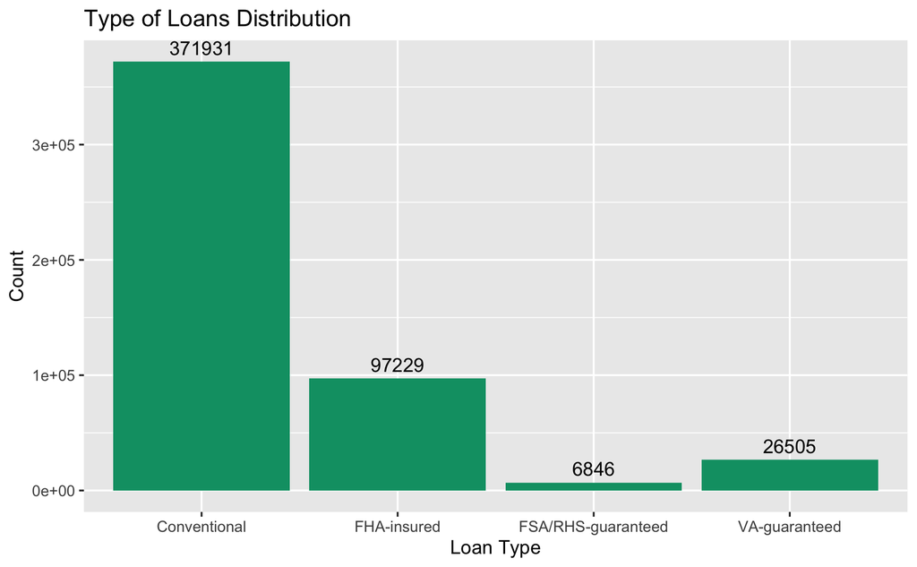

```r
graph_loan_types(hmda_il_df)
```

Looks like there are more applications for conventional loans. ### THe focus of this project is concentrated to “Conventinal Loans.”

Now lets look at the columns that give applicants Race and Ethnicity. ### Applicants Ethnicity Values

```r
unique(hmda_il_df$applicant_ethnicity_name)
```

```
[1] "Not Hispanic or Latino"
[2] "Information not provided by applicant in mail, Internet, or telephone application"
[3] "Hispanic or Latino"
[4] "Not applicable"
```

Applicant Race Encoded Numbers

```r
unique(hmda_il_df$applicant_race_1)
```

```
[1] 3 6 5 2 7 1 4
```

Applicant Race Name

```r
unique(hmda_il_df$applicant_race_name_1)
```

```
[1] "Black or African American"
[2] "Information not provided by applicant in mail, Internet, or telephone application"
[3] "White"
[4] "Asian"
[5] "Not applicable"
[6] "American Indian or Alaska Native"
[7] "Native Hawaiian or Other Pacific Islander"
```

It is convenient to merge the race and ethnicity columns. We do that here. If the ethnicity of applicant is HISPANIC or LATINO, we give the new column the value as HISPANIC or LATINO. Else the column takes the race as its value.

```r
hmda_il_df$applicant_race_and_ethnicity <- NA
hmda_il_df$co_applicant_race_and_ethnicity <- NA

hmda_il_df$applicant_race_and_ethnicity <- ifelse(hmda_il_df$applicant_ethnicity_name == "Hispanic or Latino",
       "Hispanic or Latino", hmda_il_df$applicant_race_name_1)

hmda_il_df$co_applicant_race_and_ethnicity <- ifelse(hmda_il_df$co_applicant_ethnicity_name == "Hispanic or Latino",
       "Hispanic or Latino", hmda_il_df$co_applicant_race_name_1)

hmda_il_df$applicant_race_and_ethnicity[hmda_il_df$applicant_race_and_ethnicity == "Information not provided by applicant in mail, Internet, or telephone application"] <- "No Information Provided"

head(hmda_il_df)
```

|  | as_of_year | respondent_id | agency_name | agency_abbr | agency_code | loan_type_name | loan_type | property_type_name | property_type | loan_purpose_name | loan_purpose | owner_occupancy_name | owner_occupancy | loan_amount_000s | preapproval_name | preapproval | action_taken_name | action_taken | msamd_name | msamd | state_name | state_abbr | state_code | county_name | county_code | census_tract_number | applicant_ethnicity_name | applicant_ethnicity | co_applicant_ethnicity_name | … |
| --- | --- | --- | --- | --- | --- | --- | --- | --- | --- | --- | --- | --- | --- | --- | --- | --- | --- | --- | --- | --- | --- | --- | --- | --- | --- | --- | --- | --- | --- | --- |
| 1 | 2017 | 37-1542226 | Department of Housing and Urban Development | HUD | 7 | FHA-insured | 2 | One-to-four family dwelling (other than manufactured housing) | 1 | Refinancing | 3 | Owner-occupied as a principal dwelling | 1 | 80 | Not applicable | 3 | Application withdrawn by applicant | 4 | Chicago, Naperville, Arlington Heights - IL | 16974 | Illinois | IL | 17 | Cook County | 31 | 7306.00 | Not Hispanic or Latino | 2 | No co-applicant | … |
| 2 | 2017 | 20-8921389 | Department of Housing and Urban Development | HUD | 7 | Conventional | 1 | One-to-four family dwelling (other than manufactured housing) | 1 | Refinancing | 3 | Owner-occupied as a principal dwelling | 1 | 165 | Not applicable | 3 | Loan originated | 1 | Chicago, Naperville, Arlington Heights - IL | 16974 | Illinois | IL | 17 | Cook County | 31 | 6404.00 | Information not provided by applicant in mail, Internet, or telephone application | 3 | No co-applicant | … |
| 3 | 2017 | 0000022874 | Federal Deposit Insurance Corporation | FDIC | 3 | Conventional | 1 | One-to-four family dwelling (other than manufactured housing) | 1 | Home purchase | 1 | Owner-occupied as a principal dwelling | 1 | 133 | Not applicable | 3 | Loan originated | 1 | Champaign, Urbana - IL | 16580 | Illinois | IL | 17 | Champaign County | 19 | 57.01 | Information not provided by applicant in mail, Internet, or telephone application | 3 | Information not provided by applicant in mail, Internet, or telephone application | … |
| 4 | 2017 | 0000852218 | Consumer Financial Protection Bureau | CFPB | 9 | Conventional | 1 | One-to-four family dwelling (other than manufactured housing) | 1 | Home purchase | 1 | Owner-occupied as a principal dwelling | 1 | 1112 | Not applicable | 3 | Loan originated | 1 | Chicago, Naperville, Arlington Heights - IL | 16974 | Illinois | IL | 17 | Cook County | 31 | 502.00 | Not Hispanic or Latino | 2 | No co-applicant | … |
| 5 | 2017 | 42-1739728 | Department of Housing and Urban Development | HUD | 7 | Conventional | 1 | One-to-four family dwelling (other than manufactured housing) | 1 | Refinancing | 3 | Owner-occupied as a principal dwelling | 1 | 90 | Not applicable | 3 | Application withdrawn by applicant | 4 | Chicago, Naperville, Arlington Heights - IL | 16974 | Illinois | IL | 17 | Cook County | 31 | 306.04 | Not Hispanic or Latino | 2 | No co-applicant | … |
| 6 | 2017 | 27-3863726 | Department of Housing and Urban Development | HUD | 7 | Conventional | 1 | One-to-four family dwelling (other than manufactured housing) | 1 | Home purchase | 1 | Owner-occupied as a principal dwelling | 1 | 385 | Not applicable | 3 | Loan originated | 1 | Chicago, Naperville, Arlington Heights - IL | 16974 | Illinois | IL | 17 | Cook County | 31 | 8240.04 | Not Hispanic or Latino | 2 | Not Hispanic or Latino | … |

Lets find the distributions of applicants based on their race White applicants are way more in number than that of other group of people. It is the obvious thing as minorites have less number of applicants.

One thing to note here is that a lot of applicants don’t disclose their race. We see large values for “NOT APPLICABLE” and “NO INFORMATION PROVIDED”

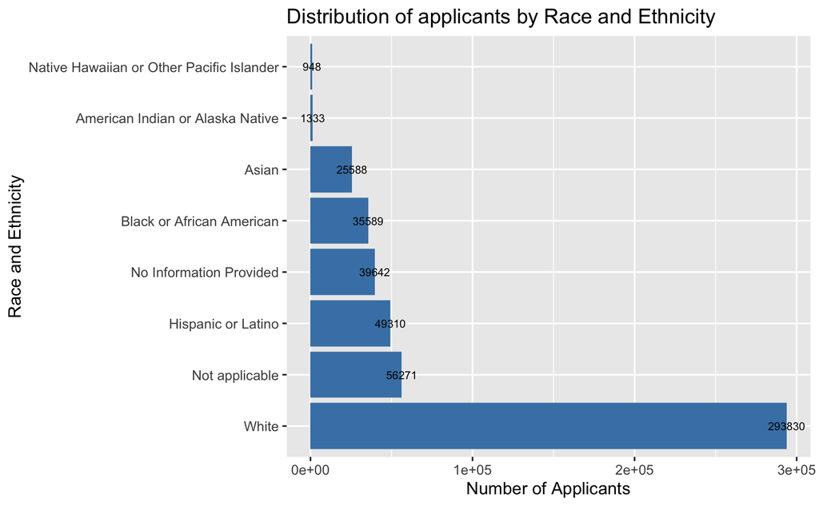

```r
count_racename <- as.data.frame(table(hmda_il_df$applicant_race_and_ethnicity))
colnames(count_racename)<-c("Race_and_Ethnicity","Count")
p<-ggplot(data=count_racename, aes(x=reorder(Race_and_Ethnicity,-Count), y=Count)) + geom_bar(stat="identity",fill="steelblue")+geom_text(aes(label=Count), size=2.5)
p + coord_flip() +labs(title = "Distribution of applicants by Race and Ethnicity", y="Number of Applicants",x="Race and Ethnicity")
```

### Applicants Income

Lets dive into the applicants income. The distribution can help us understand the spread of data.

```r
summary(hmda_il_df$applicant_income_000s)
```

```
    Min.  1st Qu.   Median     Mean  3rd Qu.     Max.     NA's
     1.0     53.0     81.0    122.8    127.0 147759.0    65583
```

Here it can be observed that the income of applicants is spreadout a lot. We have applicants with income ranging from 1 to 147759 in thousands. Also, missing values sum upto 65583. About 13% applicants income value is missing.

Also, most of the recorded income lies between 53 to 127 range

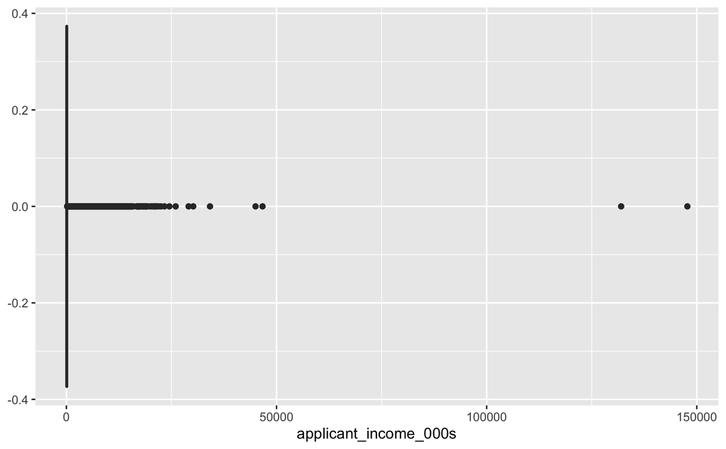

```r
ggplot(data = hmda_il_df,aes(x = applicant_income_000s)) + geom_boxplot()
```

We can clearly see there are a lot of outliers. It can also be interpreted from the summary. Lets look for the count.

### Histogram for the people having income less that 500K

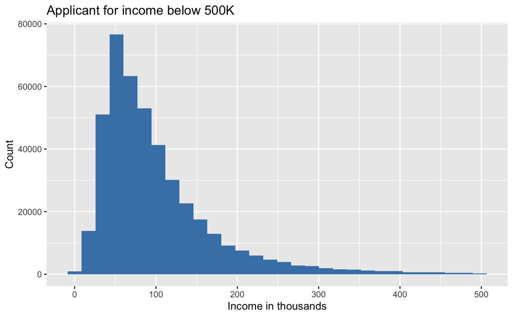

```r
temp<-as.data.frame(hmda_il_df$applicant_income_000s[hmda_il_df$applicant_income_000s<500])
ggplot(data = temp, aes(x=hmda_il_df$applicant_income_000s[hmda_il_df$applicant_income_000s < 500])) +geom_histogram(fill = "steelblue") + labs(title = "Applicant for income below 500K" , x = "Income in thousands",y="Count")
```

The distribution is right skewed. It would be better if we use median as the measure of central tendency. Lets see what % of applicants have income below 500 from the entire dataset.

```r
no_of_NAs <- sum(is.na(temp))
income_below_500<-length(hmda_il_df$applicant_income_000s[hmda_il_df$applicant_income_000s<500])
total_applicants<-length(hmda_il_df$applicant_income_000s)

((income_below_500 - no_of_NAs ) / total_applicants ) *100
```

```
[1] 85.77524
```

Approximately 86% of the total applicants have income below 500K. Among that, 13% of the values are missing.

```r
writeLines("Percent of missing values")
```

```
Percent of missing values
```

```r
sum(is.na(hmda_il_df$applicant_income_000s)) / length(hmda_il_df$applicant_income_000s)
```

```
[1] 0.1305106
```

[figure not shown]

```r
m <- summarise_at(group_by(hmda_il_df,applicant_race_and_ethnicity),vars(applicant_income_000s),funs(mean(.,na.rm=TRUE)))
ggplot(data = m ,aes (x =  reorder(applicant_race_and_ethnicity,applicant_income_000s),y = applicant_income_000s)) + geom_bar(stat = "identity",fill = "steelblue") +geom_text(aes(label=applicant_income_000s), size=3,nudge_y = 5)+ coord_flip()+labs(title = "Median of applicants income by Race and Ethnicity", y="Median Income",x="Race and Ethnicity")
```

The mean income for applicants with no information about race looks high. This maybe due to the following reason.

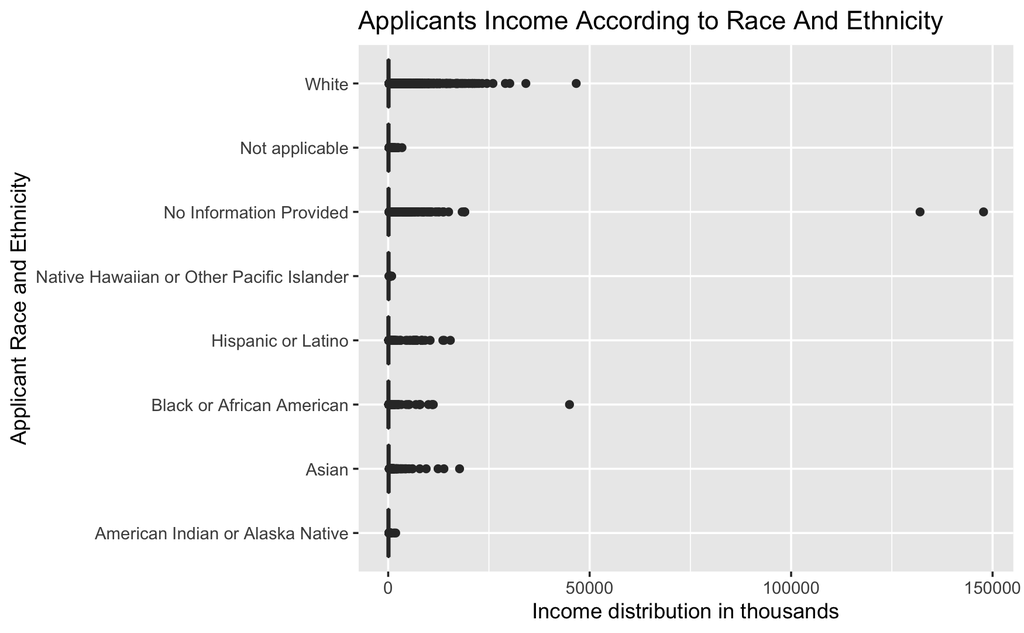

```r
p <- ggplot(group_by(hmda_il_df,applicant_race_and_ethnicity), aes(x=applicant_race_and_ethnicity, y=applicant_income_000s)) +
  geom_boxplot() + labs(title = "Applicants Income According to Race And Ethnicity" , x = "Applicant Race and Ethnicity" , y = "Income distribution in thousands")
p +coord_flip()
```

In the boxplot, the category where people didn’t provide the race and ethnicity data has most extreme values of income. These are probably outliers. This is why the mean of certain categories shifted to the higher end. Lets look in this data

### Distribution of income for the applicants with originated loans.

```r
hmda_origination_status_df <- hmda_il_df[hmda_il_df$action_taken == "1", ]
summary(hmda_origination_status_df$applicant_income_000s)
```

```
   Min. 1st Qu.  Median    Mean 3rd Qu.    Max.    NA's
    1.0    56.0    85.0   120.7   131.0 30178.0   14853
```

Lets have a look at the distribution of income for the applicants with loans originated grouped by rac and ethnicity column.

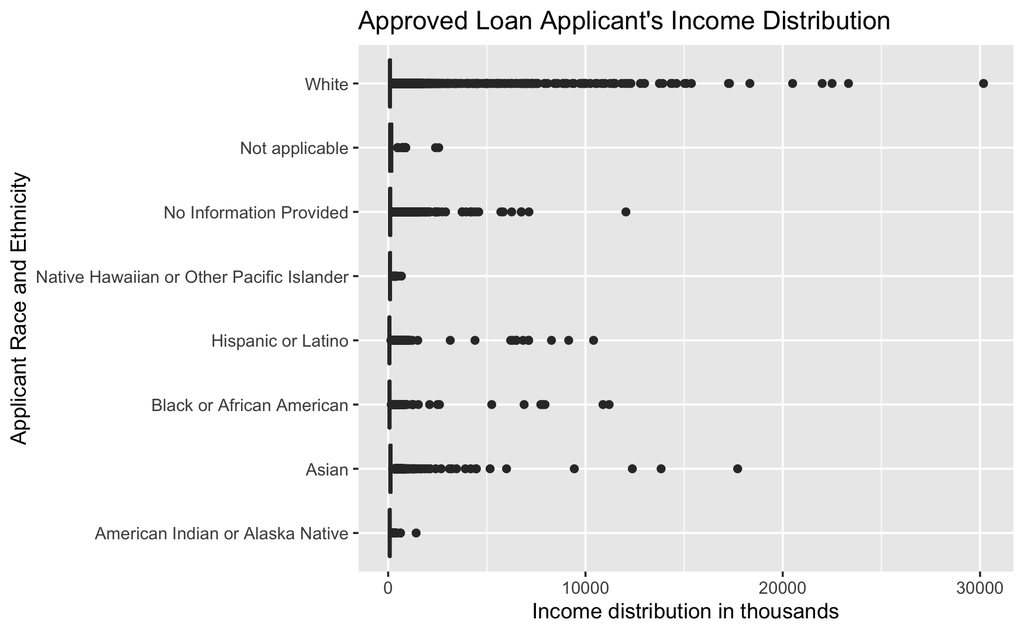

```r
p <- ggplot(group_by(hmda_origination_status_df,applicant_race_and_ethnicity), aes(x=applicant_race_and_ethnicity, y=applicant_income_000s)) +
  geom_boxplot() + labs(title = "Approved Loan Applicant's Income Distribution" , x = "Applicant Race and Ethnicity" , y = "Income distribution in thousands")
p +coord_flip()
```

As mean is a misleading measure of central tendency due to presence of outliers, maybe we can use median to see the income for applicants for loan originated is.

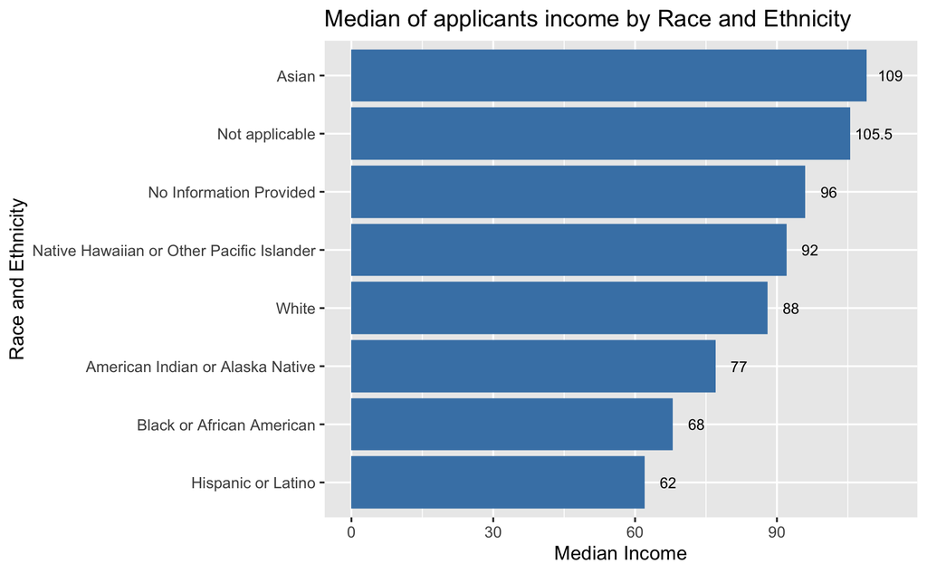

```r
m <- summarise_at(group_by(hmda_origination_status_df,applicant_race_and_ethnicity),vars(applicant_income_000s),funs(median(.,na.rm=TRUE)))
ggplot(data = m ,aes (x =  reorder(applicant_race_and_ethnicity,applicant_income_000s),y = applicant_income_000s)) + geom_bar(stat = "identity",fill = "steelblue") +geom_text(aes(label=applicant_income_000s), size=3 , nudge_y = 5)+ coord_flip()+labs(title = "Median of applicants income by Race and Ethnicity", y="Median Income",x="Race and Ethnicity")
```

This seems understandable and we can analyze it further.

Lets have a look at the distribution of applicant income of originated loans with income less than 500K. We used 500K as our max point because there are many outliers and we would not be able to see where exactly the income is concentrated as outliers are present which we say in the boxplot before.

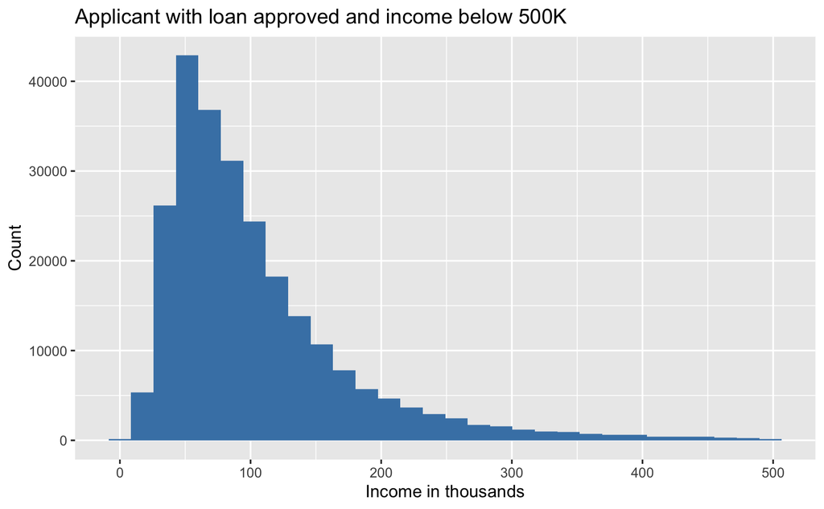

```r
temp<-as.data.frame(hmda_origination_status_df$applicant_income_000s[hmda_origination_status_df$applicant_income_000s<500])

ggplot(data = temp, aes(x=hmda_origination_status_df$applicant_income_000s[hmda_origination_status_df$applicant_income_000s < 500])) +geom_histogram(fill = "steelblue") + labs(title = "Applicant with loan approved and income below 500K" , x = "Income in thousands",y="Count")
```

### Proportion of loans originated

What are the set of decisions made for an application?

```r
unique(hmda_il_df$action_taken_name)
```

```
[1] "Application withdrawn by applicant"
[2] "Loan originated"
[3] "Application denied by financial institution"
[4] "Loan purchased by the institution"
[5] "Application approved but not accepted"
[6] "File closed for incompleteness"
[7] "Preapproval request denied by financial institution"
[8] "Preapproval request approved but not accepted"
```

```r
unique(hmda_il_df$action_taken)
```

```
[1] 4 1 3 6 2 5 7 8
```

Here, we can say the loan is denied in two ways. 1. Application denied by financial institution 2. Preapproval request denied by financial institution

The loan is approved if 1. “Application approved but not accepted” 2. “Loan originated”

Other than this, we would classify decision as “Technical or paperwork Issues” 1. “Application withdrawn by applicant” 2. “Loan purchased by the institution 3.”File closed for incompleteness" 4. “Preapproval request approved but not accepted”

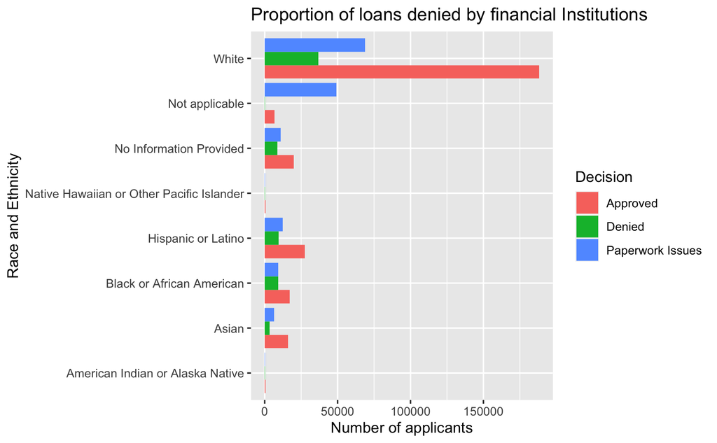

```r
hmda_il_df$Decision <- NA

hmda_il_df$Decision <- ifelse(hmda_il_df$action_taken_name == "Application denied by financial institution" | hmda_il_df$action_taken_name == "Preapproval request denied by financial institution" , "Denied" ,  ifelse(hmda_il_df$action_taken_name == "Loan originated" | hmda_il_df$action_taken_name == "Application approved but not accepted" ,  "Approved" , "Paperwork Issues"))

tbl <- with(hmda_il_df, table(Decision,applicant_race_and_ethnicity))

ggplot(as.data.frame(tbl), aes(factor(applicant_race_and_ethnicity), Freq, fill = Decision)) +
  geom_col(position = 'dodge') + labs(title = "Proportion of loans denied by financial Institutions",x = "Race and Ethnicity" , y = "Number of applicants") + coord_flip()
```

Lets plot raw action taken as see how they count.

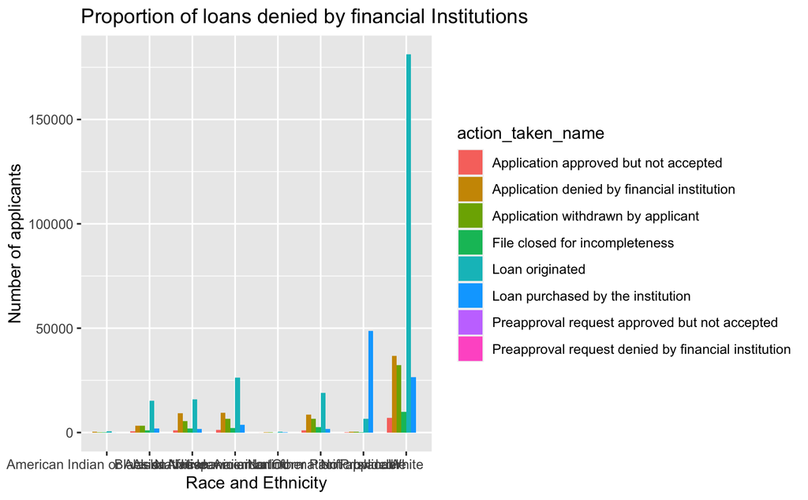

```r
tbl <- with(hmda_il_df, table(action_taken_name,applicant_race_and_ethnicity))

ggplot(as.data.frame(tbl), aes(factor(applicant_race_and_ethnicity), Freq, fill = action_taken_name)) +
  geom_col(position = 'dodge') + labs(title = "Proportion of loans denied by financial Institutions",x = "Race and Ethnicity" , y = "Number of applicants")
```

It is not clear by looking at this graph. Maybe we can plot the graph for each race and display the percent of loans accepted or denied.

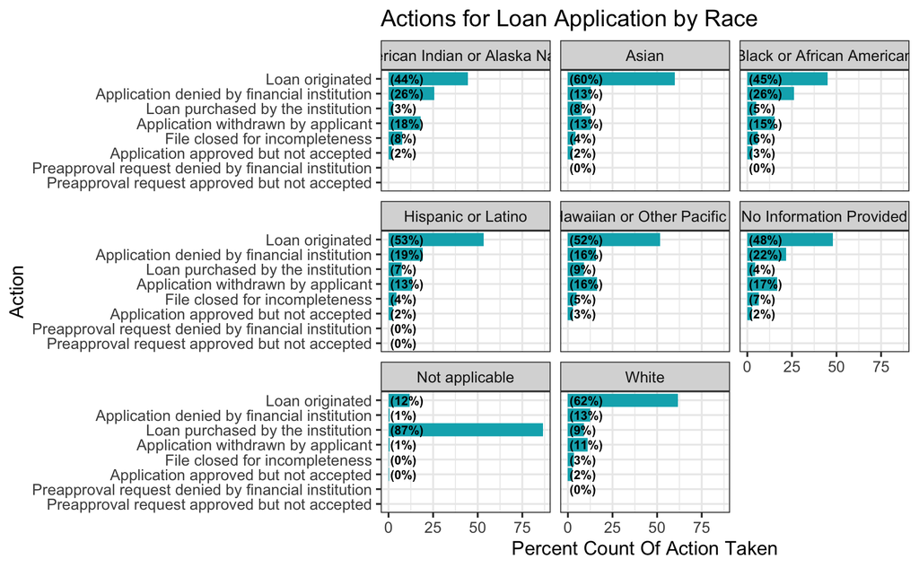

```r
mortgage_status_by_race_and_ethnicity <- hmda_il_df %>% group_by(action_taken_name, applicant_race_and_ethnicity) %>%
  summarise(ActionCount = n()) %>%
  arrange(desc(ActionCount))

mortgage_by_race_and_ethnicity = hmda_il_df %>% group_by(applicant_race_and_ethnicity) %>%
  summarise(EthnicityCount = n()) %>%
  arrange(desc(EthnicityCount))

mortgage_status_aggregated_by_race_and_ethnicity  = inner_join(mortgage_status_by_race_and_ethnicity, mortgage_by_race_and_ethnicity) %>% mutate(percentage = (ActionCount / EthnicityCount) * 100)
ggplot(mortgage_status_aggregated_by_race_and_ethnicity, aes(x = reorder(action_taken_name, percentage),
                                          y = percentage)) +
  geom_bar(stat='identity', fill ="#00AFBB") +
  facet_wrap(~ applicant_race_and_ethnicity) +
  geom_text(aes(x = action_taken_name, y = 1, label = paste0("(",round(percentage),"%)",sep="")),
            hjust=0, vjust=.5, size = 2.5, colour = 'black',
            fontface = 'bold') +
  labs(x = 'Action', y = 'Percent Count Of Action Taken', title = 'Actions for Loan Application by Race') +
  coord_flip() +
  theme_bw()
```

### Applicants loan amount

Now as we have looked more into income and decision, lets see how are the loan amounts distributed.

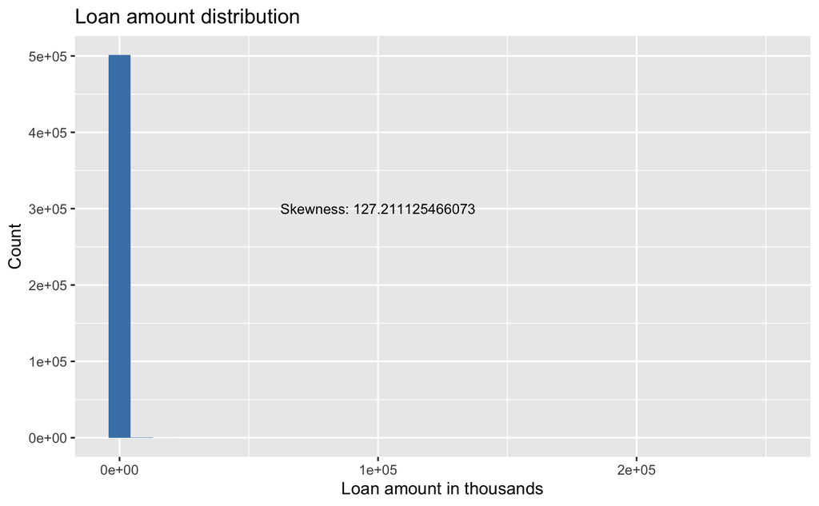

```r
library(moments)
skew <- paste("Skewness:",skewness(hmda_il_df$loan_amount_000s,na.rm = TRUE))
ggplot(data = hmda_il_df , aes(x = loan_amount_000s)) + geom_histogram(fill = "steelblue") + labs(title = "Loan amount distribution" , x = "Loan amount in thousands" , y = "Count")+ annotate("text", x = 100000, y = 300000, size = 3.2,label = skew)
```

Looks like the data is highly skewed. Lets look at the boxplot

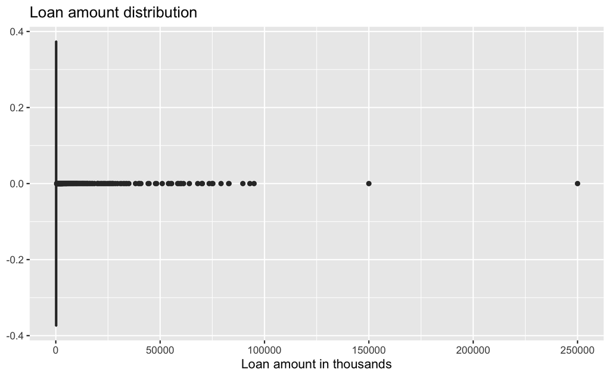

```r
ggplot(data = hmda_il_df , aes(x = loan_amount_000s)) + geom_boxplot()+ labs(title = "Loan amount distribution" , x = "Loan amount in thousands" )
```

The boxplot suggests that there a lot of outliers and possibly higher loan amounts.

```r
#install.packages("moments")
library(moments)
skewness(hmda_il_df$loan_amount_000s,na.rm = TRUE)
```

```
[1] 127.2111
```

The data for loan amount is highly right skewed. Changes should be made so that the prediction model does not mess up.

### Handling highly skewed data. Log Transformation

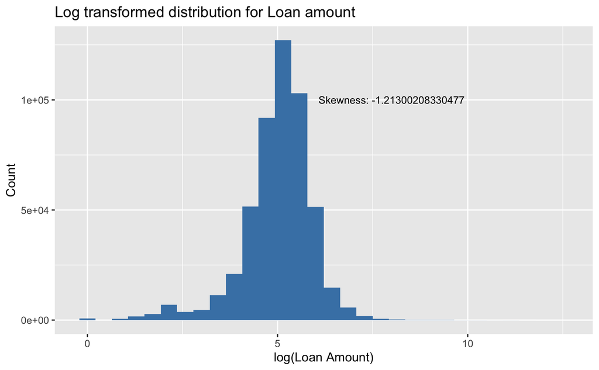

```r
skew <- paste("Skewness:",skewness(log(hmda_il_df$loan_amount_000s),na.rm = TRUE))
ggplot(data = hmda_il_df , aes(x = log(loan_amount_000s))) + geom_histogram(fill = "steelblue") + labs(title = "Log transformed distribution for Loan amount" , x = "log(Loan Amount)", y = 'Count')+ annotate("text", x = 8, y = 100000, size = 3.2,label = skew)
```

```r
skewness(log(hmda_il_df$loan_amount_000s),na.rm = TRUE)
```

```
[1] -1.213002
```

After transforming the values, the data is slightly left skewed but the value is better than without transformation.

### Same is the case with applicants income

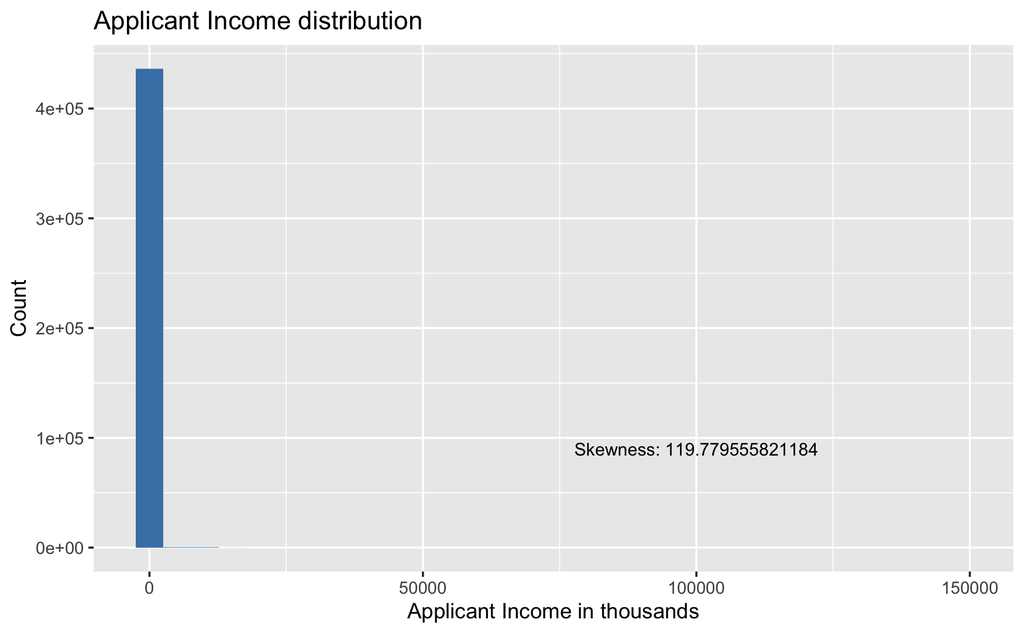

```r
skew <- paste("Skewness:",skewness(hmda_il_df$applicant_income_000s,na.rm = TRUE))
ggplot(data = hmda_il_df , aes(x = applicant_income_000s)) + geom_histogram(fill = "steelblue") + labs(title = "Applicant Income distribution" , x = "Applicant Income in thousands" , y = "Count") + annotate("text", x = 100000, y = 90000, size = 3.2,label = skew)
```

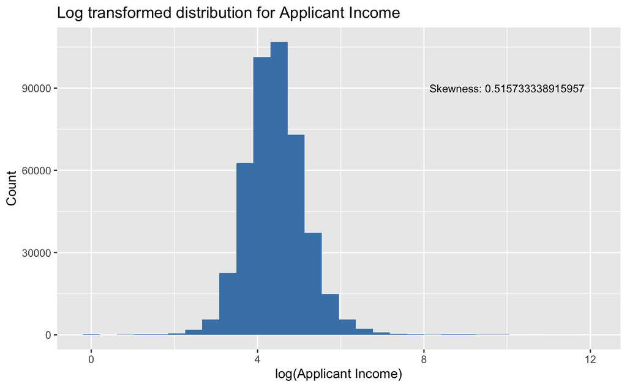

```r
skew <- paste("Skewness:",skewness(log(hmda_il_df$applicant_income_000s),na.rm=TRUE))
ggplot(data = hmda_il_df , aes(x = log(applicant_income_000s))) + geom_histogram(fill = "steelblue") + labs(title = "Log transformed distribution for Applicant Income" , x = "log(Applicant Income)", y = 'Count') +annotate("text", x = 10, y = 90000, size = 3.2,label = skew)
```

### Which columns have most values missing?

```r
m<-sapply(hmda_il_df, function(x) sum(is.na(x)))
temp<-c()
for (i in 1:length(m)){
  if(m[i]>0){
    temp<-c(temp,m[i])
  }
}
missing <- data.frame(temp)
missing$percent <- (missing$temp / length(hmda_il_df$as_of_year))*100
missing
```

|  | temp | percent |
| --- | --- | --- |
| loan_amount_000s | 938 | 0.1866626 |
| msamd | 36285 | 7.2207375 |
| county_code | 875 | 0.1741255 |
| census_tract_number | 1132 | 0.2252687 |
| applicant_race_2 | 500399 | 99.5797107 |
| applicant_race_3 | 502367 | 99.9713439 |
| applicant_race_4 | 502470 | 99.9918410 |
| applicant_race_5 | 502490 | 99.9958210 |
| co_applicant_race_2 | 501812 | 99.8608986 |
| co_applicant_race_3 | 502475 | 99.9928360 |

[output cut: 17 more lines]

From the dataframe above, we can see that there are a lot of columns with missing values more that 90%. We can’t impute these values with very less prior data. Also, these columns would not provide any information while making the decision of whether to grant a loan or not.

Other perpective to look at this is, a lot of applicants don’t have the information about these predictors. So most probably, banks don’t use this information to make decision.

Hence, we can get rid of this columns. This can reduce dimensionality of our dataset.

```r
drop<- c ("applicant_race_2",
          "applicant_race_3",
          "applicant_race_4",
          "applicant_race_5",
          "co_applicant_race_2",
          "co_applicant_race_3",
          "co_applicant_race_4",
          "co_applicant_race_5",
          "denial_reason_1",
          "denial_reason_2",
          "denial_reason_3",
          "edit_status_name",
          "edit_status",
          "rate_spread",
          "sequence_number",
          "application_date_indicator",
          "as_of_year", # Does not provide extra information which can be used
          "respondent_id", # Does not provide extra information which can be used
          "agency_abbr", # Does not provide extra information which can be used
          "agency_name", # Does not provide extra information which can be used
          "loan_type_name", # We are only dealing with conventional loans.
          "loan_type",
          "state_abbr",# Not needed as data is of same state
          "state_code", # Not needed as data is of same state
          "owner_occupancy_name", # Redundant column. Encoded values present
          "msamd_name", # Redundant column. Encoded values present
          "state_name", # Redundant column. Encoded values present
          "applicant_sex_name", # Redundant column. Encoded values present
          "hoepa_status_name", # Redundant column. Encoded values present
          "lien_status_name", # Redundant column. Encoded values present
          "county_name", # Redundant column. Encoded values present
          "preapproval_name", # Redundant column. Encoded values present
          "property_type_name", # Redundant column. Encoded values present
          "action_taken_name", # Redundant column. Encoded values present
          "loan_purpose_name", # Redundant column. Encoded values present
          "purchaser_type_name", # Redundant column. Encoded values present
          "applicant_ethnicity_name", # Redundant column. Encoded values present
          "co_applicant_ethnicity_name", # Redundant column. Encoded values present
          "co_applicant_sex_name" ) # Redundant column. Encoded values present
hmda_il_df<-hmda_il_df[ , !(names(hmda_il_df) %in% drop)]
dim(hmda_il_df)
```

```
[1] 502511     42
```

Append a new column which has binary value about the decision. If the application is decides as “Loan Originated” or “Purchased by Institution”, it is considered as loan granted with positive value, else the loan is denied, 0.

```r
hmda_il_df$loan_granted <- ifelse(hmda_il_df$action_taken == 1 | hmda_il_df$action_taken == 6, 1, 0)
```

```r
colnames(hmda_il_df)
```

```
 [1] "agency_code"                     "property_type"
 [3] "loan_purpose"                    "owner_occupancy"
 [5] "loan_amount_000s"                "preapproval"
 [7] "action_taken"                    "msamd"
 [9] "county_code"                     "census_tract_number"
[11] "applicant_ethnicity"             "co_applicant_ethnicity"
[13] "applicant_race_name_1"           "applicant_race_1"
[15] "applicant_race_name_2"           "applicant_race_name_3"
[17] "applicant_race_name_4"           "applicant_race_name_5"
[19] "co_applicant_race_name_1"        "co_applicant_race_1"
[21] "co_applicant_race_name_2"        "co_applicant_race_name_3"
[23] "co_applicant_race_name_4"        "co_applicant_race_name_5"
[25] "applicant_sex"                   "co_applicant_sex"
[27] "applicant_income_000s"           "purchaser_type"
[29] "denial_reason_name_1"            "denial_reason_name_2"
[31] "denial_reason_name_3"            "hoepa_status"
[33] "lien_status"                     "population"
[35] "minority_population"             "hud_median_family_income"
[37] "tract_to_msamd_income"           "number_of_owner_occupied_units"
[39] "number_of_1_to_4_family_units"   "applicant_race_and_ethnicity"
[41] "co_applicant_race_and_ethnicity" "Decision"
[43] "loan_granted"
```

### Feature Importances.

As we have narrowed the list down, lets look which factors influence the decision whether the loan is granted or not. For this we can use XGBoost to find the feature importances. This can help us get started and use the predictors which influences the decision. Following function call helps us do that.

|  | Variables | Importance | Rank |
| --- | --- | --- | --- |
| 1 | purchaser_type | 100.00 | #1 |
| 2 | DecisionDenied | 40.92 | #2 |
| 3 | DecisionPaperwork.Issues | 40.29 | #3 |
| 4 | lien_status | 29.03 | #4 |
| 5 | applicant_race_name_1Not.applicable | 3.48 | #5 |
| 6 | applicant_ethnicity | 2.94 | #6 |
| 7 | agency_code | 2.77 | #7 |
| 8 | denial_reason_name_1Credit.history | 1.98 | #8 |
| 9 | denial_reason_name_1Debt.to.income.ratio | 1.88 | #9 |
| 10 | loan_purpose | 0.21 | #10 |

[output cut: 10 more lines]

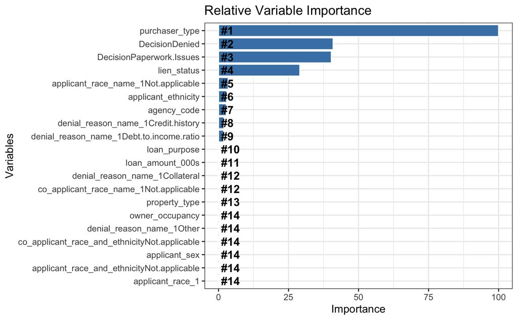

```r
feature_importances(dataf = hmda_il_df , number_of_top_features = 20)
```

Here are some important features that can be used to model our data. But hang on! Some of them does not make sense. What I mean by that is, if we look at lien status and purchase type, those the variables which get their values after the decision is made. Meaning, if we want to decide whether applicant is getting a loan approved or not, we can’t use them as we wont have them while we want to predict. This is where we need some domain knowledge and apply it to make the models more sensible.

### Final Thoughts

1. We look at the data and walked through various steps like getting to know the data, find number of missing values, columns that we can use and important features.
2. Regarding the problem of investigation, we can say that there could be some bias while tha application of the laon is being made on the grounds of Race and Ethnicity. We are missing some key information and can’t make any legitimate claims. But barely scratching the surface, this is what we see.
3. Further investigation is needed and by building models, we can see how they perform by taking into account race and ethnicity and by excluding them.
4. There are lot of missing values. We need to handle them and also scale our data so that one feature does not dominate the decsion making. Data Cleaning is gonna be a tiring process but will sure help.

Some colors with their codes which can are used for graphs.

```r
cbp2 <- c("#000000", "#E69F00", "#56B4E9", "#009E73",          "#F0E442", "#0072B2", "#D55E00", "#CC79A7")
```